# Risk Factor Analysis

## Outcome Variable

**Outcome Variable:** ever_stunted

## Predictor Variables

**Intervention Variable:** hhwealth_quart

**Adjustment Set:**

unadjusted

## Stratifying Variables

The analysis was stratified on these variable(s):

- agecat
- studyid
- country

## Data Summary

| agecat | studyid | country | A | n | nA | nAY0 | nAY1 |
| --- | --- | --- | --- | --- | --- | --- | --- |
| 3 months | ki0047075b-MAL-ED | BANGLADESH | Wealth Q4 | 82 | 26 | 22 | 4 |
| 3 months | ki0047075b-MAL-ED | BANGLADESH | Wealth Q1 | 82 | 4 | 2 | 2 |
| 3 months | ki0047075b-MAL-ED | BANGLADESH | Wealth Q2 | 82 | 15 | 12 | 3 |
| 3 months | ki0047075b-MAL-ED | BANGLADESH | Wealth Q3 | 82 | 37 | 23 | 14 |
| 3 months | ki0047075b-MAL-ED | BRAZIL | Wealth Q4 | 3 | 2 | 0 | 2 |
| 3 months | ki0047075b-MAL-ED | BRAZIL | Wealth Q1 | 3 | 0 | 0 | 0 |
| 3 months | ki0047075b-MAL-ED | BRAZIL | Wealth Q2 | 3 | 1 | 0 | 1 |
| 3 months | ki0047075b-MAL-ED | BRAZIL | Wealth Q3 | 3 | 0 | 0 | 0 |
| 3 months | ki0047075b-MAL-ED | INDIA | Wealth Q4 | 71 | 29 | 21 | 8 |
| 3 months | ki0047075b-MAL-ED | INDIA | Wealth Q1 | 71 | 1 | 1 | 0 |
| 3 months | ki0047075b-MAL-ED | INDIA | Wealth Q2 | 71 | 10 | 7 | 3 |
| 3 months | ki0047075b-MAL-ED | INDIA | Wealth Q3 | 71 | 31 | 22 | 9 |
| 3 months | ki0047075b-MAL-ED | NEPAL | Wealth Q4 | 42 | 21 | 15 | 6 |
| 3 months | ki0047075b-MAL-ED | NEPAL | Wealth Q1 | 42 | 11 | 9 | 2 |
| 3 months | ki0047075b-MAL-ED | NEPAL | Wealth Q2 | 42 | 6 | 5 | 1 |
| 3 months | ki0047075b-MAL-ED | NEPAL | Wealth Q3 | 42 | 4 | 3 | 1 |
| 3 months | ki0047075b-MAL-ED | PERU | Wealth Q4 | 37 | 1 | 1 | 0 |
| 3 months | ki0047075b-MAL-ED | PERU | Wealth Q1 | 37 | 24 | 15 | 9 |
| 3 months | ki0047075b-MAL-ED | PERU | Wealth Q2 | 37 | 11 | 6 | 5 |
| 3 months | ki0047075b-MAL-ED | PERU | Wealth Q3 | 37 | 1 | 1 | 0 |
| 3 months | ki0047075b-MAL-ED | SOUTH AFRICA | Wealth Q4 | 68 | 13 | 10 | 3 |
| 3 months | ki0047075b-MAL-ED | SOUTH AFRICA | Wealth Q1 | 68 | 12 | 10 | 2 |
| 3 months | ki0047075b-MAL-ED | SOUTH AFRICA | Wealth Q2 | 68 | 24 | 22 | 2 |
| 3 months | ki0047075b-MAL-ED | SOUTH AFRICA | Wealth Q3 | 68 | 19 | 11 | 8 |
| 3 months | ki0047075b-MAL-ED | TANZANIA, UNITED REPUBLIC OF | Wealth Q4 | 60 | 0 | 0 | 0 |
| 3 months | ki0047075b-MAL-ED | TANZANIA, UNITED REPUBLIC OF | Wealth Q1 | 60 | 39 | 30 | 9 |
| 3 months | ki0047075b-MAL-ED | TANZANIA, UNITED REPUBLIC OF | Wealth Q2 | 60 | 21 | 15 | 6 |
| 3 months | ki0047075b-MAL-ED | TANZANIA, UNITED REPUBLIC OF | Wealth Q3 | 60 | 0 | 0 | 0 |
| 3 months | ki1000108-CMC-V-BCS-2002 | INDIA | Wealth Q4 | 362 | 92 | 47 | 45 |
| 3 months | ki1000108-CMC-V-BCS-2002 | INDIA | Wealth Q1 | 362 | 90 | 71 | 19 |

[output cut: 326 more lines]

The following strata were considered:

- agecat: 12 months, studyid: ki0047075b-MAL-ED, country: BANGLADESH
- agecat: 12 months, studyid: ki0047075b-MAL-ED, country: BRAZIL
- agecat: 12 months, studyid: ki0047075b-MAL-ED, country: INDIA
- agecat: 12 months, studyid: ki0047075b-MAL-ED, country: NEPAL
- agecat: 12 months, studyid: ki0047075b-MAL-ED, country: PERU
- agecat: 12 months, studyid: ki0047075b-MAL-ED, country: SOUTH AFRICA
- agecat: 12 months, studyid: ki0047075b-MAL-ED, country: TANZANIA, UNITED REPUBLIC OF
- agecat: 12 months, studyid: ki1000108-CMC-V-BCS-2002, country: INDIA
- agecat: 12 months, studyid: ki1000108-IRC, country: INDIA
- agecat: 12 months, studyid: ki1017093b-PROVIDE, country: BANGLADESH
- agecat: 12 months, studyid: ki1066203-TanzaniaChild2, country: TANZANIA, UNITED REPUBLIC OF
- agecat: 12 months, studyid: ki1113344-GMS-Nepal, country: NEPAL
- agecat: 12 months, studyid: ki1114097-CONTENT, country: PERU
- agecat: 12 months, studyid: ki1135781-COHORTS, country: GUATEMALA
- agecat: 12 months, studyid: ki1135781-COHORTS, country: PHILIPPINES
- agecat: 12 months, studyid: ki1148112-LCNI-5, country: MALAWI
- agecat: 12 months, studyid: kiGH5241-JiVitA-3, country: BANGLADESH
- agecat: 12 months, studyid: kiGH5241-JiVitA-4, country: BANGLADESH
- agecat: 18 months, studyid: ki0047075b-MAL-ED, country: BANGLADESH
- agecat: 18 months, studyid: ki0047075b-MAL-ED, country: BRAZIL
- agecat: 18 months, studyid: ki0047075b-MAL-ED, country: INDIA
- agecat: 18 months, studyid: ki0047075b-MAL-ED, country: NEPAL
- agecat: 18 months, studyid: ki0047075b-MAL-ED, country: PERU
- agecat: 18 months, studyid: ki0047075b-MAL-ED, country: SOUTH AFRICA
- agecat: 18 months, studyid: ki0047075b-MAL-ED, country: TANZANIA, UNITED REPUBLIC OF
- agecat: 18 months, studyid: ki1000108-CMC-V-BCS-2002, country: INDIA
- agecat: 18 months, studyid: ki1000108-IRC, country: INDIA
- agecat: 18 months, studyid: ki1017093b-PROVIDE, country: BANGLADESH
- agecat: 18 months, studyid: ki1066203-TanzaniaChild2, country: TANZANIA, UNITED REPUBLIC OF
- agecat: 18 months, studyid: ki1113344-GMS-Nepal, country: NEPAL
- agecat: 18 months, studyid: ki1114097-CONTENT, country: PERU
- agecat: 18 months, studyid: ki1135781-COHORTS, country: GUATEMALA
- agecat: 18 months, studyid: ki1135781-COHORTS, country: PHILIPPINES
- agecat: 18 months, studyid: ki1148112-LCNI-5, country: MALAWI
- agecat: 18 months, studyid: kiGH5241-JiVitA-3, country: BANGLADESH
- agecat: 18 months, studyid: kiGH5241-JiVitA-4, country: BANGLADESH
- agecat: 24 months, studyid: ki0047075b-MAL-ED, country: BANGLADESH
- agecat: 24 months, studyid: ki0047075b-MAL-ED, country: BRAZIL
- agecat: 24 months, studyid: ki0047075b-MAL-ED, country: INDIA
- agecat: 24 months, studyid: ki0047075b-MAL-ED, country: NEPAL
- agecat: 24 months, studyid: ki0047075b-MAL-ED, country: PERU
- agecat: 24 months, studyid: ki0047075b-MAL-ED, country: SOUTH AFRICA
- agecat: 24 months, studyid: ki0047075b-MAL-ED, country: TANZANIA, UNITED REPUBLIC OF
- agecat: 24 months, studyid: ki1000108-CMC-V-BCS-2002, country: INDIA
- agecat: 24 months, studyid: ki1000108-IRC, country: INDIA
- agecat: 24 months, studyid: ki1017093b-PROVIDE, country: BANGLADESH
- agecat: 24 months, studyid: ki1066203-TanzaniaChild2, country: TANZANIA, UNITED REPUBLIC OF
- agecat: 24 months, studyid: ki1113344-GMS-Nepal, country: NEPAL
- agecat: 24 months, studyid: ki1114097-CONTENT, country: PERU
- agecat: 24 months, studyid: ki1135781-COHORTS, country: GUATEMALA
- agecat: 24 months, studyid: ki1135781-COHORTS, country: PHILIPPINES
- agecat: 24 months, studyid: ki1148112-LCNI-5, country: MALAWI
- agecat: 24 months, studyid: kiGH5241-JiVitA-3, country: BANGLADESH
- agecat: 24 months, studyid: kiGH5241-JiVitA-4, country: BANGLADESH
- agecat: 3 months, studyid: ki0047075b-MAL-ED, country: BANGLADESH
- agecat: 3 months, studyid: ki0047075b-MAL-ED, country: BRAZIL
- agecat: 3 months, studyid: ki0047075b-MAL-ED, country: INDIA
- agecat: 3 months, studyid: ki0047075b-MAL-ED, country: NEPAL
- agecat: 3 months, studyid: ki0047075b-MAL-ED, country: PERU
- agecat: 3 months, studyid: ki0047075b-MAL-ED, country: SOUTH AFRICA
- agecat: 3 months, studyid: ki0047075b-MAL-ED, country: TANZANIA, UNITED REPUBLIC OF
- agecat: 3 months, studyid: ki1000108-CMC-V-BCS-2002, country: INDIA
- agecat: 3 months, studyid: ki1000108-IRC, country: INDIA
- agecat: 3 months, studyid: ki1017093b-PROVIDE, country: BANGLADESH
- agecat: 3 months, studyid: ki1066203-TanzaniaChild2, country: TANZANIA, UNITED REPUBLIC OF
- agecat: 3 months, studyid: ki1113344-GMS-Nepal, country: NEPAL
- agecat: 3 months, studyid: ki1114097-CONTENT, country: PERU
- agecat: 3 months, studyid: ki1135781-COHORTS, country: GUATEMALA
- agecat: 3 months, studyid: ki1135781-COHORTS, country: PHILIPPINES
- agecat: 3 months, studyid: kiGH5241-JiVitA-3, country: BANGLADESH
- agecat: 3 months, studyid: kiGH5241-JiVitA-4, country: BANGLADESH
- agecat: 6 months, studyid: ki0047075b-MAL-ED, country: BANGLADESH
- agecat: 6 months, studyid: ki0047075b-MAL-ED, country: BRAZIL
- agecat: 6 months, studyid: ki0047075b-MAL-ED, country: INDIA
- agecat: 6 months, studyid: ki0047075b-MAL-ED, country: NEPAL
- agecat: 6 months, studyid: ki0047075b-MAL-ED, country: PERU
- agecat: 6 months, studyid: ki0047075b-MAL-ED, country: SOUTH AFRICA
- agecat: 6 months, studyid: ki0047075b-MAL-ED, country: TANZANIA, UNITED REPUBLIC OF
- agecat: 6 months, studyid: ki1000108-CMC-V-BCS-2002, country: INDIA
- agecat: 6 months, studyid: ki1000108-IRC, country: INDIA
- agecat: 6 months, studyid: ki1017093b-PROVIDE, country: BANGLADESH
- agecat: 6 months, studyid: ki1066203-TanzaniaChild2, country: TANZANIA, UNITED REPUBLIC OF
- agecat: 6 months, studyid: ki1113344-GMS-Nepal, country: NEPAL
- agecat: 6 months, studyid: ki1114097-CONTENT, country: PERU
- agecat: 6 months, studyid: ki1135781-COHORTS, country: GUATEMALA
- agecat: 6 months, studyid: ki1135781-COHORTS, country: PHILIPPINES
- agecat: 6 months, studyid: ki1148112-LCNI-5, country: MALAWI
- agecat: 6 months, studyid: kiGH5241-JiVitA-3, country: BANGLADESH
- agecat: 6 months, studyid: kiGH5241-JiVitA-4, country: BANGLADESH

### Dropped Strata

Some strata were dropped due to rare outcomes:

- agecat: 3 months, studyid: ki0047075b-MAL-ED, country: BANGLADESH
- agecat: 3 months, studyid: ki0047075b-MAL-ED, country: BRAZIL
- agecat: 3 months, studyid: ki0047075b-MAL-ED, country: INDIA
- agecat: 3 months, studyid: ki0047075b-MAL-ED, country: NEPAL
- agecat: 3 months, studyid: ki0047075b-MAL-ED, country: PERU
- agecat: 3 months, studyid: ki0047075b-MAL-ED, country: SOUTH AFRICA
- agecat: 3 months, studyid: ki0047075b-MAL-ED, country: TANZANIA, UNITED REPUBLIC OF
- agecat: 6 months, studyid: ki0047075b-MAL-ED, country: BANGLADESH
- agecat: 6 months, studyid: ki0047075b-MAL-ED, country: BRAZIL
- agecat: 6 months, studyid: ki0047075b-MAL-ED, country: INDIA
- agecat: 6 months, studyid: ki0047075b-MAL-ED, country: NEPAL
- agecat: 6 months, studyid: ki0047075b-MAL-ED, country: PERU
- agecat: 6 months, studyid: ki0047075b-MAL-ED, country: SOUTH AFRICA
- agecat: 6 months, studyid: ki0047075b-MAL-ED, country: TANZANIA, UNITED REPUBLIC OF
- agecat: 12 months, studyid: ki0047075b-MAL-ED, country: BANGLADESH
- agecat: 12 months, studyid: ki0047075b-MAL-ED, country: BRAZIL
- agecat: 12 months, studyid: ki0047075b-MAL-ED, country: INDIA
- agecat: 12 months, studyid: ki0047075b-MAL-ED, country: NEPAL
- agecat: 12 months, studyid: ki0047075b-MAL-ED, country: PERU
- agecat: 12 months, studyid: ki0047075b-MAL-ED, country: SOUTH AFRICA
- agecat: 12 months, studyid: ki0047075b-MAL-ED, country: TANZANIA, UNITED REPUBLIC OF
- agecat: 18 months, studyid: ki0047075b-MAL-ED, country: BANGLADESH
- agecat: 18 months, studyid: ki0047075b-MAL-ED, country: BRAZIL
- agecat: 18 months, studyid: ki0047075b-MAL-ED, country: INDIA
- agecat: 18 months, studyid: ki0047075b-MAL-ED, country: NEPAL
- agecat: 18 months, studyid: ki0047075b-MAL-ED, country: PERU
- agecat: 18 months, studyid: ki0047075b-MAL-ED, country: TANZANIA, UNITED REPUBLIC OF
- agecat: 24 months, studyid: ki0047075b-MAL-ED, country: BANGLADESH
- agecat: 24 months, studyid: ki0047075b-MAL-ED, country: BRAZIL
- agecat: 24 months, studyid: ki0047075b-MAL-ED, country: INDIA
- agecat: 24 months, studyid: ki0047075b-MAL-ED, country: NEPAL
- agecat: 24 months, studyid: ki0047075b-MAL-ED, country: PERU
- agecat: 24 months, studyid: ki0047075b-MAL-ED, country: SOUTH AFRICA
- agecat: 24 months, studyid: ki0047075b-MAL-ED, country: TANZANIA, UNITED REPUBLIC OF
- agecat: 24 months, studyid: ki1135781-COHORTS, country: GUATEMALA
- agecat: 24 months, studyid: kiGH5241-JiVitA-3, country: BANGLADESH

## Methods Detail

We’re interested in the causal parameters $E[Y_a]$ for all values of $a \in \mathcal{A}$. These parameters represent the mean outcome if, possibly contrary to fact, we intervened to set all units to have $A=a$. Under the randomization and positivity assumptions, these are identified by the statistical parameters $\psi_a=E_W[E_{Y|A,W}(Y|A=a,W)]$. In addition, we’re interested in the mean of $Y$, $E[Y]$ under no intervention (the observed mean). We will estimate these parameters by using SuperLearner to fit the relevant likelihood factors – $E_{Y|A,W}(Y|A=a,W)$ and $p(A=a|W)$, and then updating our likelihood fit using a joint TMLE.

For unadjusted analyses ($W=\{\}$), initial likelihoods were estimated using Lrnr_glm to estimate the simple $E(Y|A)$ and Lrnr_mean to estimate $p(A)$. For adjusted analyses, a small library containing Lrnr_glmnet, Lrnr_xgboost, and Lrnr_mean was used.

Having estimated these parameters, we will then use the delta method to estimate relative risks and attributable risks relative to a prespecified baseline level of $A$.

# Results Detail

## Results Plots

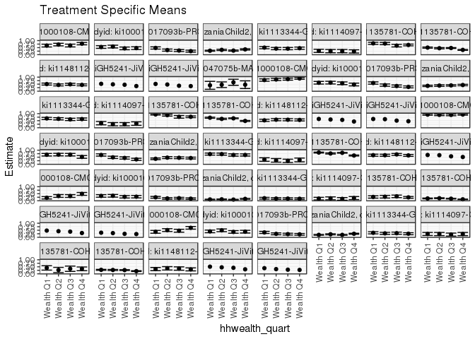

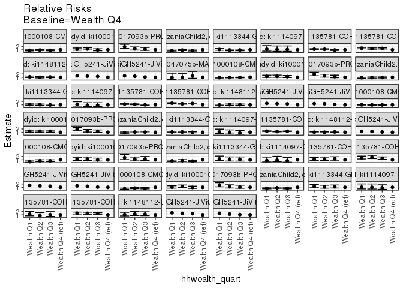

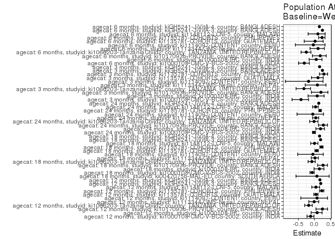

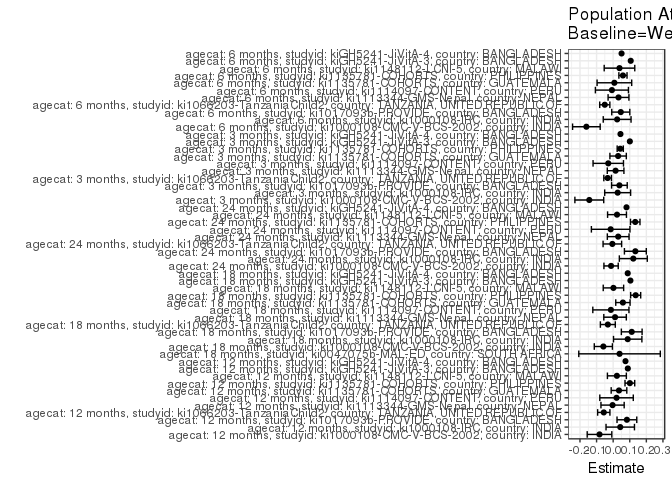

## Results Table

### Parameter: TSM

| agecat | studyid | country | intervention_level | baseline_level | estimate | ci_lower | ci_upper |
| --- | --- | --- | --- | --- | --- | --- | --- |
| 3 months | ki1000108-CMC-V-BCS-2002 | INDIA | Wealth Q4 | NA | 0.4891304 | 0.3868430 | 0.5914179 |
| 3 months | ki1000108-CMC-V-BCS-2002 | INDIA | Wealth Q1 | NA | 0.2111111 | 0.1266822 | 0.2955400 |
| 3 months | ki1000108-CMC-V-BCS-2002 | INDIA | Wealth Q2 | NA | 0.3406593 | 0.2431507 | 0.4381680 |
| 3 months | ki1000108-CMC-V-BCS-2002 | INDIA | Wealth Q3 | NA | 0.3370787 | 0.2387341 | 0.4354232 |
| 3 months | ki1000108-IRC | INDIA | Wealth Q4 | NA | 0.2900000 | 0.2009556 | 0.3790444 |
| 3 months | ki1000108-IRC | INDIA | Wealth Q1 | NA | 0.3428571 | 0.2519558 | 0.4337585 |
| 3 months | ki1000108-IRC | INDIA | Wealth Q2 | NA | 0.3529412 | 0.2600870 | 0.4457953 |
| 3 months | ki1000108-IRC | INDIA | Wealth Q3 | NA | 0.2815534 | 0.1945898 | 0.3685170 |
| 3 months | ki1017093b-PROVIDE | BANGLADESH | Wealth Q4 | NA | 0.1485714 | 0.0958385 | 0.2013044 |
| 3 months | ki1017093b-PROVIDE | BANGLADESH | Wealth Q1 | NA | 0.2444444 | 0.1816174 | 0.3072715 |
| 3 months | ki1017093b-PROVIDE | BANGLADESH | Wealth Q2 | NA | 0.1656805 | 0.1095863 | 0.2217747 |
| 3 months | ki1017093b-PROVIDE | BANGLADESH | Wealth Q3 | NA | 0.1839080 | 0.1263038 | 0.2415123 |
| 3 months | ki1066203-TanzaniaChild2 | TANZANIA, UNITED REPUBLIC OF | Wealth Q4 | NA | 0.1353638 | 0.1077762 | 0.1629514 |
| 3 months | ki1066203-TanzaniaChild2 | TANZANIA, UNITED REPUBLIC OF | Wealth Q1 | NA | 0.0919220 | 0.0707848 | 0.1130593 |
| 3 months | ki1066203-TanzaniaChild2 | TANZANIA, UNITED REPUBLIC OF | Wealth Q2 | NA | 0.1014493 | 0.0745177 | 0.1283808 |
| 3 months | ki1066203-TanzaniaChild2 | TANZANIA, UNITED REPUBLIC OF | Wealth Q3 | NA | 0.0814941 | 0.0593944 | 0.1035937 |
| 3 months | ki1113344-GMS-Nepal | NEPAL | Wealth Q4 | NA | 0.1438356 | 0.0868651 | 0.2008061 |
| 3 months | ki1113344-GMS-Nepal | NEPAL | Wealth Q1 | NA | 0.1800000 | 0.1184664 | 0.2415336 |
| 3 months | ki1113344-GMS-Nepal | NEPAL | Wealth Q2 | NA | 0.1554054 | 0.0969882 | 0.2138226 |
| 3 months | ki1113344-GMS-Nepal | NEPAL | Wealth Q3 | NA | 0.1543624 | 0.0963014 | 0.2124234 |
| 3 months | ki1114097-CONTENT | PERU | Wealth Q4 | NA | 0.1923077 | 0.0849384 | 0.2996770 |
| 3 months | ki1114097-CONTENT | PERU | Wealth Q1 | NA | 0.1525424 | 0.0605846 | 0.2445002 |
| 3 months | ki1114097-CONTENT | PERU | Wealth Q2 | NA | 0.1730769 | 0.0700120 | 0.2761419 |
| 3 months | ki1114097-CONTENT | PERU | Wealth Q3 | NA | 0.1346154 | 0.0416309 | 0.2275999 |
| 3 months | ki1135781-COHORTS | GUATEMALA | Wealth Q4 | NA | 0.2419355 | 0.1803263 | 0.3035447 |
| 3 months | ki1135781-COHORTS | GUATEMALA | Wealth Q1 | NA | 0.2710280 | 0.1867199 | 0.3553362 |
| 3 months | ki1135781-COHORTS | GUATEMALA | Wealth Q2 | NA | 0.2873563 | 0.1921675 | 0.3825452 |
| 3 months | ki1135781-COHORTS | GUATEMALA | Wealth Q3 | NA | 0.3137255 | 0.2235844 | 0.4038666 |
| 3 months | ki1135781-COHORTS | PHILIPPINES | Wealth Q4 | NA | 0.1020166 | 0.0815816 | 0.1224516 |
| 3 months | ki1135781-COHORTS | PHILIPPINES | Wealth Q1 | NA | 0.1644833 | 0.1367578 | 0.1922088 |

[output cut: 182 more lines]

### Parameter: E(Y)

| agecat | studyid | country | intervention_level | baseline_level | estimate | ci_lower | ci_upper |
| --- | --- | --- | --- | --- | --- | --- | --- |
| 3 months | ki1000108-CMC-V-BCS-2002 | INDIA | NA | NA | 0.3453039 | 0.2962566 | 0.3943512 |
| 3 months | ki1000108-IRC | INDIA | NA | NA | 0.3170732 | 0.2719756 | 0.3621708 |
| 3 months | ki1017093b-PROVIDE | BANGLADESH | NA | NA | 0.1862464 | 0.1573448 | 0.2151480 |
| 3 months | ki1066203-TanzaniaChild2 | TANZANIA, UNITED REPUBLIC OF | NA | NA | 0.1020580 | 0.0898959 | 0.1142200 |
| 3 months | ki1113344-GMS-Nepal | NEPAL | NA | NA | 0.1585160 | 0.1290957 | 0.1879363 |
| 3 months | ki1114097-CONTENT | PERU | NA | NA | 0.1627907 | 0.1133285 | 0.2122529 |
| 3 months | ki1135781-COHORTS | GUATEMALA | NA | NA | 0.2717842 | 0.2320269 | 0.3115416 |
| 3 months | ki1135781-COHORTS | PHILIPPINES | NA | NA | 0.1446809 | 0.1322046 | 0.1571571 |
| 3 months | kiGH5241-JiVitA-3 | BANGLADESH | NA | NA | 0.4034299 | NA | NA |
| 3 months | kiGH5241-JiVitA-4 | BANGLADESH | NA | NA | 0.2735931 | NA | NA |
| 6 months | ki1000108-CMC-V-BCS-2002 | INDIA | NA | NA | 0.5122616 | 0.4610525 | 0.5634707 |
| 6 months | ki1000108-IRC | INDIA | NA | NA | 0.4240196 | 0.3760078 | 0.4720314 |
| 6 months | ki1017093b-PROVIDE | BANGLADESH | NA | NA | 0.2554859 | 0.2216172 | 0.2893546 |
| 6 months | ki1066203-TanzaniaChild2 | TANZANIA, UNITED REPUBLIC OF | NA | NA | 0.2000000 | 0.1833758 | 0.2166242 |
| 6 months | ki1113344-GMS-Nepal | NEPAL | NA | NA | 0.2857143 | 0.2484972 | 0.3229313 |
| 6 months | ki1114097-CONTENT | PERU | NA | NA | 0.2232558 | 0.1674626 | 0.2790491 |
| 6 months | ki1135781-COHORTS | GUATEMALA | NA | NA | 0.3602941 | 0.2793100 | 0.4412783 |
| 6 months | ki1135781-COHORTS | PHILIPPINES | NA | NA | 0.2499109 | 0.2338855 | 0.2659362 |
| 6 months | ki1148112-LCNI-5 | MALAWI | NA | NA | 0.3531599 | 0.2959376 | 0.4103821 |
| 6 months | kiGH5241-JiVitA-3 | BANGLADESH | NA | NA | 0.4254743 | NA | NA |
| 6 months | kiGH5241-JiVitA-4 | BANGLADESH | NA | NA | 0.3273961 | NA | NA |
| 12 months | ki1000108-CMC-V-BCS-2002 | INDIA | NA | NA | 0.6989247 | 0.6522466 | 0.7456029 |
| 12 months | ki1000108-IRC | INDIA | NA | NA | 0.5073529 | 0.4587823 | 0.5559236 |
| 12 months | ki1017093b-PROVIDE | BANGLADESH | NA | NA | 0.3327842 | 0.2952673 | 0.3703010 |
| 12 months | ki1066203-TanzaniaChild2 | TANZANIA, UNITED REPUBLIC OF | NA | NA | 0.3174044 | 0.2969382 | 0.3378706 |
| 12 months | ki1113344-GMS-Nepal | NEPAL | NA | NA | 0.4553265 | 0.4148326 | 0.4958204 |
| 12 months | ki1114097-CONTENT | PERU | NA | NA | 0.2511628 | 0.1930579 | 0.3092677 |
| 12 months | ki1135781-COHORTS | GUATEMALA | NA | NA | 0.7238095 | 0.6855271 | 0.7620919 |
| 12 months | ki1135781-COHORTS | PHILIPPINES | NA | NA | 0.4388125 | 0.4203024 | 0.4573225 |
| 12 months | ki1148112-LCNI-5 | MALAWI | NA | NA | 0.4710327 | 0.4362910 | 0.5057745 |
| 12 months | kiGH5241-JiVitA-3 | BANGLADESH | NA | NA | 0.4516784 | NA | NA |
| 12 months | kiGH5241-JiVitA-4 | BANGLADESH | NA | NA | 0.4341085 | NA | NA |
| 18 months | ki0047075b-MAL-ED | SOUTH AFRICA | NA | NA | 0.5000000 | 0.3802761 | 0.6197239 |
| 18 months | ki1000108-CMC-V-BCS-2002 | INDIA | NA | NA | 0.8471850 | 0.8106214 | 0.8837486 |
| 18 months | ki1000108-IRC | INDIA | NA | NA | 0.5623472 | 0.5142095 | 0.6104849 |
| 18 months | ki1017093b-PROVIDE | BANGLADESH | NA | NA | 0.4162521 | 0.3768752 | 0.4556289 |
| 18 months | ki1066203-TanzaniaChild2 | TANZANIA, UNITED REPUBLIC OF | NA | NA | 0.4053867 | 0.3800899 | 0.4306836 |
| 18 months | ki1113344-GMS-Nepal | NEPAL | NA | NA | 0.6236934 | 0.5840266 | 0.6633602 |
| 18 months | ki1114097-CONTENT | PERU | NA | NA | 0.2803738 | 0.2200512 | 0.3406965 |
| 18 months | ki1135781-COHORTS | GUATEMALA | NA | NA | 0.8352668 | 0.8002064 | 0.8703272 |
| 18 months | ki1135781-COHORTS | PHILIPPINES | NA | NA | 0.6166413 | 0.5980630 | 0.6352197 |
| 18 months | ki1148112-LCNI-5 | MALAWI | NA | NA | 0.5535714 | 0.5159574 | 0.5911854 |
| 18 months | kiGH5241-JiVitA-3 | BANGLADESH | NA | NA | 0.5434694 | NA | NA |
| 18 months | kiGH5241-JiVitA-4 | BANGLADESH | NA | NA | 0.5477753 | NA | NA |
| 24 months | ki1000108-CMC-V-BCS-2002 | INDIA | NA | NA | 0.9249330 | 0.8981563 | 0.9517096 |
| 24 months | ki1000108-IRC | INDIA | NA | NA | 0.6414634 | 0.5949863 | 0.6879405 |
| 24 months | ki1017093b-PROVIDE | BANGLADESH | NA | NA | 0.4802065 | 0.4395469 | 0.5208662 |
| 24 months | ki1066203-TanzaniaChild2 | TANZANIA, UNITED REPUBLIC OF | NA | NA | 0.4342380 | 0.4028349 | 0.4656411 |
| 24 months | ki1113344-GMS-Nepal | NEPAL | NA | NA | 0.6901408 | 0.6520774 | 0.7282042 |
| 24 months | ki1114097-CONTENT | PERU | NA | NA | 0.2893401 | 0.2258574 | 0.3528228 |
| 24 months | ki1135781-COHORTS | PHILIPPINES | NA | NA | 0.7525371 | 0.7358238 | 0.7692504 |
| 24 months | ki1148112-LCNI-5 | MALAWI | NA | NA | 0.6513889 | 0.6165572 | 0.6862206 |
| 24 months | kiGH5241-JiVitA-4 | BANGLADESH | NA | NA | 0.5949791 | NA | NA |

### Parameter: RR

| agecat | studyid | country | intervention_level | baseline_level | estimate | ci_lower | ci_upper |
| --- | --- | --- | --- | --- | --- | --- | --- |
| 3 months | ki1000108-CMC-V-BCS-2002 | INDIA | Wealth Q4 | Wealth Q4 | 1.0000000 | 1.0000000 | 1.0000000 |
| 3 months | ki1000108-CMC-V-BCS-2002 | INDIA | Wealth Q1 | Wealth Q4 | 0.4316049 | 0.2748457 | 0.6777725 |
| 3 months | ki1000108-CMC-V-BCS-2002 | INDIA | Wealth Q2 | Wealth Q4 | 0.6964591 | 0.4885885 | 0.9927686 |
| 3 months | ki1000108-CMC-V-BCS-2002 | INDIA | Wealth Q3 | Wealth Q4 | 0.6891386 | 0.4812956 | 0.9867367 |
| 3 months | ki1000108-IRC | INDIA | Wealth Q4 | Wealth Q4 | 1.0000000 | 1.0000000 | 1.0000000 |
| 3 months | ki1000108-IRC | INDIA | Wealth Q1 | Wealth Q4 | 1.1822660 | 0.7880114 | 1.7737725 |
| 3 months | ki1000108-IRC | INDIA | Wealth Q2 | Wealth Q4 | 1.2170385 | 0.8122691 | 1.8235124 |
| 3 months | ki1000108-IRC | INDIA | Wealth Q3 | Wealth Q4 | 0.9708738 | 0.6280836 | 1.5007492 |
| 3 months | ki1017093b-PROVIDE | BANGLADESH | Wealth Q4 | Wealth Q4 | 1.0000000 | 1.0000000 | 1.0000000 |
| 3 months | ki1017093b-PROVIDE | BANGLADESH | Wealth Q1 | Wealth Q4 | 1.6452991 | 1.0615204 | 2.5501247 |
| 3 months | ki1017093b-PROVIDE | BANGLADESH | Wealth Q2 | Wealth Q4 | 1.1151570 | 0.6828219 | 1.8212292 |
| 3 months | ki1017093b-PROVIDE | BANGLADESH | Wealth Q3 | Wealth Q4 | 1.2378426 | 0.7710456 | 1.9872421 |
| 3 months | ki1066203-TanzaniaChild2 | TANZANIA, UNITED REPUBLIC OF | Wealth Q4 | Wealth Q4 | 1.0000000 | 1.0000000 | 1.0000000 |
| 3 months | ki1066203-TanzaniaChild2 | TANZANIA, UNITED REPUBLIC OF | Wealth Q1 | Wealth Q4 | 0.6790738 | 0.4994288 | 0.9233373 |
| 3 months | ki1066203-TanzaniaChild2 | TANZANIA, UNITED REPUBLIC OF | Wealth Q2 | Wealth Q4 | 0.7494565 | 0.5362876 | 1.0473579 |
| 3 months | ki1066203-TanzaniaChild2 | TANZANIA, UNITED REPUBLIC OF | Wealth Q3 | Wealth Q4 | 0.6020374 | 0.4288436 | 0.8451774 |
| 3 months | ki1113344-GMS-Nepal | NEPAL | Wealth Q4 | Wealth Q4 | 1.0000000 | 1.0000000 | 1.0000000 |
| 3 months | ki1113344-GMS-Nepal | NEPAL | Wealth Q1 | Wealth Q4 | 1.2514286 | 0.7416193 | 2.1116945 |
| 3 months | ki1113344-GMS-Nepal | NEPAL | Wealth Q2 | Wealth Q4 | 1.0804376 | 0.6258187 | 1.8653091 |
| 3 months | ki1113344-GMS-Nepal | NEPAL | Wealth Q3 | Wealth Q4 | 1.0731863 | 0.6215193 | 1.8530863 |
| 3 months | ki1114097-CONTENT | PERU | Wealth Q4 | Wealth Q4 | 1.0000000 | 1.0000000 | 1.0000000 |
| 3 months | ki1114097-CONTENT | PERU | Wealth Q1 | Wealth Q4 | 0.7932203 | 0.3487786 | 1.8040053 |
| 3 months | ki1114097-CONTENT | PERU | Wealth Q2 | Wealth Q4 | 0.9000000 | 0.3978628 | 2.0358778 |
| 3 months | ki1114097-CONTENT | PERU | Wealth Q3 | Wealth Q4 | 0.7000000 | 0.2879855 | 1.7014746 |
| 3 months | ki1135781-COHORTS | GUATEMALA | Wealth Q4 | Wealth Q4 | 1.0000000 | 1.0000000 | 1.0000000 |
| 3 months | ki1135781-COHORTS | GUATEMALA | Wealth Q1 | Wealth Q4 | 1.1202492 | 0.7494190 | 1.6745751 |
| 3 months | ki1135781-COHORTS | GUATEMALA | Wealth Q2 | Wealth Q4 | 1.1877395 | 0.7820988 | 1.8037682 |
| 3 months | ki1135781-COHORTS | GUATEMALA | Wealth Q3 | Wealth Q4 | 1.2967320 | 0.8833061 | 1.9036593 |
| 3 months | ki1135781-COHORTS | PHILIPPINES | Wealth Q4 | Wealth Q4 | 1.0000000 | 1.0000000 | 1.0000000 |
| 3 months | ki1135781-COHORTS | PHILIPPINES | Wealth Q1 | Wealth Q4 | 1.6123185 | 1.2409497 | 2.0948236 |

[output cut: 182 more lines]

### Parameter: PAR

| agecat | studyid | country | intervention_level | baseline_level | estimate | ci_lower | ci_upper |
| --- | --- | --- | --- | --- | --- | --- | --- |
| 3 months | ki1000108-CMC-V-BCS-2002 | INDIA | Wealth Q4 | NA | -0.1438266 | -0.2307190 | -0.0569342 |
| 3 months | ki1000108-IRC | INDIA | Wealth Q4 | NA | 0.0270732 | -0.0509969 | 0.1051432 |
| 3 months | ki1017093b-PROVIDE | BANGLADESH | Wealth Q4 | NA | 0.0376750 | -0.0094599 | 0.0848099 |
| 3 months | ki1066203-TanzaniaChild2 | TANZANIA, UNITED REPUBLIC OF | Wealth Q4 | NA | -0.0333058 | -0.0563530 | -0.0102587 |
| 3 months | ki1113344-GMS-Nepal | NEPAL | Wealth Q4 | NA | 0.0146804 | -0.0354494 | 0.0648102 |
| 3 months | ki1114097-CONTENT | PERU | Wealth Q4 | NA | -0.0295170 | -0.1211590 | 0.0621250 |
| 3 months | ki1135781-COHORTS | GUATEMALA | Wealth Q4 | NA | 0.0298487 | -0.0196173 | 0.0793148 |
| 3 months | ki1135781-COHORTS | PHILIPPINES | Wealth Q4 | NA | 0.0426642 | 0.0241498 | 0.0611787 |
| 3 months | kiGH5241-JiVitA-3 | BANGLADESH | Wealth Q4 | NA | 0.1006234 | NA | NA |
| 3 months | kiGH5241-JiVitA-4 | BANGLADESH | Wealth Q4 | NA | 0.0440211 | NA | NA |
| 6 months | ki1000108-CMC-V-BCS-2002 | INDIA | Wealth Q4 | NA | -0.1614226 | -0.2446169 | -0.0782284 |
| 6 months | ki1000108-IRC | INDIA | Wealth Q4 | NA | 0.0240196 | -0.0597468 | 0.1077860 |
| 6 months | ki1017093b-PROVIDE | BANGLADESH | Wealth Q4 | NA | 0.0459051 | -0.0085525 | 0.1003626 |
| 6 months | ki1066203-TanzaniaChild2 | TANZANIA, UNITED REPUBLIC OF | Wealth Q4 | NA | -0.0504537 | -0.0810680 | -0.0198395 |
| 6 months | ki1113344-GMS-Nepal | NEPAL | Wealth Q4 | NA | 0.0321932 | -0.0306155 | 0.0950018 |
| 6 months | ki1114097-CONTENT | PERU | Wealth Q4 | NA | -0.0075134 | -0.1070869 | 0.0920601 |
| 6 months | ki1135781-COHORTS | GUATEMALA | Wealth Q4 | NA | 0.0073529 | -0.0970057 | 0.1117115 |
| 6 months | ki1135781-COHORTS | PHILIPPINES | Wealth Q4 | NA | 0.0590018 | 0.0344160 | 0.0835876 |
| 6 months | ki1148112-LCNI-5 | MALAWI | Wealth Q4 | NA | 0.0380914 | -0.0540297 | 0.1302124 |
| 6 months | kiGH5241-JiVitA-3 | BANGLADESH | Wealth Q4 | NA | 0.1058307 | NA | NA |
| 6 months | kiGH5241-JiVitA-4 | BANGLADESH | Wealth Q4 | NA | 0.0506433 | NA | NA |
| 12 months | ki1000108-CMC-V-BCS-2002 | INDIA | Wealth Q4 | NA | -0.0823253 | -0.1564653 | -0.0081853 |
| 12 months | ki1000108-IRC | INDIA | Wealth Q4 | NA | 0.0427065 | -0.0429634 | 0.1283764 |
| 12 months | ki1017093b-PROVIDE | BANGLADESH | Wealth Q4 | NA | 0.0827842 | 0.0232904 | 0.1422780 |
| 12 months | ki1066203-TanzaniaChild2 | TANZANIA, UNITED REPUBLIC OF | Wealth Q4 | NA | -0.0565625 | -0.0936128 | -0.0195122 |
| 12 months | ki1113344-GMS-Nepal | NEPAL | Wealth Q4 | NA | -0.0035776 | -0.0735836 | 0.0664283 |
| 12 months | ki1114097-CONTENT | PERU | Wealth Q4 | NA | 0.0203936 | -0.0804934 | 0.1212805 |
| 12 months | ki1135781-COHORTS | GUATEMALA | Wealth Q4 | NA | 0.0351303 | -0.0119267 | 0.0821872 |
| 12 months | ki1135781-COHORTS | PHILIPPINES | Wealth Q4 | NA | 0.1006354 | 0.0713780 | 0.1298929 |
| 12 months | ki1148112-LCNI-5 | MALAWI | Wealth Q4 | NA | 0.0224346 | -0.0346297 | 0.0794989 |
| 12 months | kiGH5241-JiVitA-3 | BANGLADESH | Wealth Q4 | NA | 0.0883088 | NA | NA |
| 12 months | kiGH5241-JiVitA-4 | BANGLADESH | Wealth Q4 | NA | 0.0743524 | NA | NA |
| 18 months | ki0047075b-MAL-ED | SOUTH AFRICA | Wealth Q4 | NA | 0.0384615 | -0.2072395 | 0.2841626 |
| 18 months | ki1000108-CMC-V-BCS-2002 | INDIA | Wealth Q4 | NA | -0.0590650 | -0.1137556 | -0.0043744 |
| 18 months | ki1000108-IRC | INDIA | Wealth Q4 | NA | 0.0875997 | 0.0020357 | 0.1731637 |
| 18 months | ki1017093b-PROVIDE | BANGLADESH | Wealth Q4 | NA | 0.1119042 | 0.0493860 | 0.1744225 |
| 18 months | ki1066203-TanzaniaChild2 | TANZANIA, UNITED REPUBLIC OF | Wealth Q4 | NA | -0.0321133 | -0.0770668 | 0.0128402 |
| 18 months | ki1113344-GMS-Nepal | NEPAL | Wealth Q4 | NA | 0.0114485 | -0.0564117 | 0.0793087 |
| 18 months | ki1114097-CONTENT | PERU | Wealth Q4 | NA | -0.0137438 | -0.1226547 | 0.0951671 |
| 18 months | ki1135781-COHORTS | GUATEMALA | Wealth Q4 | NA | 0.0587305 | 0.0155860 | 0.1018750 |
| 18 months | ki1135781-COHORTS | PHILIPPINES | Wealth Q4 | NA | 0.1356115 | 0.1053445 | 0.1658786 |
| 18 months | ki1148112-LCNI-5 | MALAWI | Wealth Q4 | NA | 0.0016589 | -0.0598411 | 0.0631588 |
| 18 months | kiGH5241-JiVitA-3 | BANGLADESH | Wealth Q4 | NA | 0.1040610 | NA | NA |
| 18 months | kiGH5241-JiVitA-4 | BANGLADESH | Wealth Q4 | NA | 0.0877114 | NA | NA |
| 24 months | ki1000108-CMC-V-BCS-2002 | INDIA | Wealth Q4 | NA | -0.0125670 | -0.0556692 | 0.0305351 |
| 24 months | ki1000108-IRC | INDIA | Wealth Q4 | NA | 0.1214634 | 0.0373017 | 0.2056252 |
| 24 months | ki1017093b-PROVIDE | BANGLADESH | Wealth Q4 | NA | 0.1338013 | 0.0678583 | 0.1997443 |
| 24 months | ki1066203-TanzaniaChild2 | TANZANIA, UNITED REPUBLIC OF | Wealth Q4 | NA | -0.0048924 | -0.0608101 | 0.0510252 |
| 24 months | ki1113344-GMS-Nepal | NEPAL | Wealth Q4 | NA | 0.0302769 | -0.0351690 | 0.0957228 |
| 24 months | ki1114097-CONTENT | PERU | Wealth Q4 | NA | -0.0150077 | -0.1312053 | 0.1011899 |
| 24 months | ki1135781-COHORTS | PHILIPPINES | Wealth Q4 | NA | 0.1330316 | 0.1044572 | 0.1616060 |
| 24 months | ki1148112-LCNI-5 | MALAWI | Wealth Q4 | NA | 0.0232482 | -0.0336075 | 0.0801039 |
| 24 months | kiGH5241-JiVitA-4 | BANGLADESH | Wealth Q4 | NA | 0.0803805 | NA | NA |

### Parameter: PAF

| agecat | studyid | country | intervention_level | baseline_level | estimate | ci_lower | ci_upper |
| --- | --- | --- | --- | --- | --- | --- | --- |
| 3 months | ki1000108-CMC-V-BCS-2002 | INDIA | Wealth Q4 | NA | -0.4165217 | -0.6959809 | -0.1831111 |
| 3 months | ki1000108-IRC | INDIA | Wealth Q4 | NA | 0.0853846 | -0.1971050 | 0.3012131 |
| 3 months | ki1017093b-PROVIDE | BANGLADESH | Wealth Q4 | NA | 0.2022857 | -0.0938422 | 0.4182451 |
| 3 months | ki1066203-TanzaniaChild2 | TANZANIA, UNITED REPUBLIC OF | Wealth Q4 | NA | -0.3263423 | -0.5697445 | -0.1206817 |
| 3 months | ki1113344-GMS-Nepal | NEPAL | Wealth Q4 | NA | 0.0926115 | -0.2853078 | 0.3594111 |
| 3 months | ki1114097-CONTENT | PERU | Wealth Q4 | NA | -0.1813187 | -0.9001531 | 0.2655782 |
| 3 months | ki1135781-COHORTS | GUATEMALA | Wealth Q4 | NA | 0.1098252 | -0.0918294 | 0.2742353 |
| 3 months | ki1135781-COHORTS | PHILIPPINES | Wealth Q4 | NA | 0.2948852 | 0.1568910 | 0.4102935 |
| 3 months | kiGH5241-JiVitA-3 | BANGLADESH | Wealth Q4 | NA | 0.2494199 | NA | NA |
| 3 months | kiGH5241-JiVitA-4 | BANGLADESH | Wealth Q4 | NA | 0.1608999 | NA | NA |
| 6 months | ki1000108-CMC-V-BCS-2002 | INDIA | Wealth Q4 | NA | -0.3151176 | -0.4939838 | -0.1576660 |
| 6 months | ki1000108-IRC | INDIA | Wealth Q4 | NA | 0.0566474 | -0.1631640 | 0.2349195 |
| 6 months | ki1017093b-PROVIDE | BANGLADESH | Wealth Q4 | NA | 0.1796775 | -0.0629763 | 0.3669388 |
| 6 months | ki1066203-TanzaniaChild2 | TANZANIA, UNITED REPUBLIC OF | Wealth Q4 | NA | -0.2522686 | -0.4144807 | -0.1086589 |
| 6 months | ki1113344-GMS-Nepal | NEPAL | Wealth Q4 | NA | 0.1126761 | -0.1365983 | 0.3072805 |
| 6 months | ki1114097-CONTENT | PERU | Wealth Q4 | NA | -0.0336538 | -0.5913044 | 0.3285758 |
| 6 months | ki1135781-COHORTS | GUATEMALA | Wealth Q4 | NA | 0.0204082 | -0.3166192 | 0.2711635 |
| 6 months | ki1135781-COHORTS | PHILIPPINES | Wealth Q4 | NA | 0.2360913 | 0.1317495 | 0.3278938 |
| 6 months | ki1148112-LCNI-5 | MALAWI | Wealth Q4 | NA | 0.1078587 | -0.1951078 | 0.3340215 |
| 6 months | kiGH5241-JiVitA-3 | BANGLADESH | Wealth Q4 | NA | 0.2487359 | NA | NA |
| 6 months | kiGH5241-JiVitA-4 | BANGLADESH | Wealth Q4 | NA | 0.1546852 | NA | NA |
| 12 months | ki1000108-CMC-V-BCS-2002 | INDIA | Wealth Q4 | NA | -0.1177885 | -0.2303989 | -0.0154845 |
| 12 months | ki1000108-IRC | INDIA | Wealth Q4 | NA | 0.0841751 | -0.1014555 | 0.2385210 |
| 12 months | ki1017093b-PROVIDE | BANGLADESH | Wealth Q4 | NA | 0.2487624 | 0.0476218 | 0.4074224 |
| 12 months | ki1066203-TanzaniaChild2 | TANZANIA, UNITED REPUBLIC OF | Wealth Q4 | NA | -0.1782033 | -0.3009702 | -0.0670214 |
| 12 months | ki1113344-GMS-Nepal | NEPAL | Wealth Q4 | NA | -0.0078573 | -0.1739546 | 0.1347396 |
| 12 months | ki1114097-CONTENT | PERU | Wealth Q4 | NA | 0.0811966 | -0.4223497 | 0.4064753 |
| 12 months | ki1135781-COHORTS | GUATEMALA | Wealth Q4 | NA | 0.0485353 | -0.0189663 | 0.1115652 |
| 12 months | ki1135781-COHORTS | PHILIPPINES | Wealth Q4 | NA | 0.2293359 | 0.1595357 | 0.2933392 |
| 12 months | ki1148112-LCNI-5 | MALAWI | Wealth Q4 | NA | 0.0476286 | -0.0816017 | 0.1614183 |
| 12 months | kiGH5241-JiVitA-3 | BANGLADESH | Wealth Q4 | NA | 0.1955125 | NA | NA |
| 12 months | kiGH5241-JiVitA-4 | BANGLADESH | Wealth Q4 | NA | 0.1712761 | NA | NA |
| 18 months | ki0047075b-MAL-ED | SOUTH AFRICA | Wealth Q4 | NA | 0.0769231 | -0.5724357 | 0.4581203 |
| 18 months | ki1000108-CMC-V-BCS-2002 | INDIA | Wealth Q4 | NA | -0.0697191 | -0.1370671 | -0.0063602 |
| 18 months | ki1000108-IRC | INDIA | Wealth Q4 | NA | 0.1557751 | -0.0117705 | 0.2955758 |
| 18 months | ki1017093b-PROVIDE | BANGLADESH | Wealth Q4 | NA | 0.2688377 | 0.1019926 | 0.4046838 |
| 18 months | ki1066203-TanzaniaChild2 | TANZANIA, UNITED REPUBLIC OF | Wealth Q4 | NA | -0.0792164 | -0.1960616 | 0.0262141 |
| 18 months | ki1113344-GMS-Nepal | NEPAL | Wealth Q4 | NA | 0.0183559 | -0.0967225 | 0.1213593 |
| 18 months | ki1114097-CONTENT | PERU | Wealth Q4 | NA | -0.0490196 | -0.5191154 | 0.2756033 |
| 18 months | ki1135781-COHORTS | GUATEMALA | Wealth Q4 | NA | 0.0703135 | 0.0164516 | 0.1212257 |
| 18 months | ki1135781-COHORTS | PHILIPPINES | Wealth Q4 | NA | 0.2199196 | 0.1685444 | 0.2681204 |
| 18 months | ki1148112-LCNI-5 | MALAWI | Wealth Q4 | NA | 0.0029967 | -0.1145266 | 0.1081274 |
| 18 months | kiGH5241-JiVitA-3 | BANGLADESH | Wealth Q4 | NA | 0.1914753 | NA | NA |
| 18 months | kiGH5241-JiVitA-4 | BANGLADESH | Wealth Q4 | NA | 0.1601230 | NA | NA |
| 24 months | ki1000108-CMC-V-BCS-2002 | INDIA | Wealth Q4 | NA | -0.0135870 | -0.0613168 | 0.0319963 |
| 24 months | ki1000108-IRC | INDIA | Wealth Q4 | NA | 0.1893536 | 0.0453406 | 0.3116419 |
| 24 months | ki1017093b-PROVIDE | BANGLADESH | Wealth Q4 | NA | 0.2786328 | 0.1265553 | 0.4042318 |
| 24 months | ki1066203-TanzaniaChild2 | TANZANIA, UNITED REPUBLIC OF | Wealth Q4 | NA | -0.0112667 | -0.1485983 | 0.1096449 |
| 24 months | ki1113344-GMS-Nepal | NEPAL | Wealth Q4 | NA | 0.0438706 | -0.0559323 | 0.1342405 |
| 24 months | ki1114097-CONTENT | PERU | Wealth Q4 | NA | -0.0518688 | -0.5408566 | 0.2819397 |
| 24 months | ki1135781-COHORTS | PHILIPPINES | Wealth Q4 | NA | 0.1767774 | 0.1370743 | 0.2146539 |
| 24 months | ki1148112-LCNI-5 | MALAWI | Wealth Q4 | NA | 0.0356902 | -0.0557252 | 0.1191899 |
| 24 months | kiGH5241-JiVitA-4 | BANGLADESH | Wealth Q4 | NA | 0.1350981 | NA | NA |